# Activity 1 — Task 4: Continuous Salary Regression Modeling

Group 08

This section addresses the first research question: how accurately can we predict the salary of a Data Science professional worldwide, and which factors drive income levels? We model `salary_in_usd` through its natural logarithm `log_salary`, because the exploratory analysis showed a strongly right-skewed distribution with a handful of legitimate executive-level salaries; working on the log scale accommodates that skew without discarding real observations, and it gives coefficients a convenient percentage interpretation.

Seven model specifications are constructed and their assumptions tested: a **multiple linear regression**, first with all available predictors and then reduced by stepwise selection; a **polynomial regression** that lets the numeric predictors bend away from a straight line; **Ridge**, **LASSO**, and their **elastic-net** mixture with a cross-validated mixing weight, which stabilize estimates when many dummy variables share the workload; and a final linear model fitted on the Box–Cox-optimal power transform $\text{salary}^{\lambda}$. All fitting, tuning, and assumption testing use the training data only; the held-out records are kept untouched here and are formally scored and compared in Task 6.

```r
library(tidyverse)
library(glmnet)
library(car)
library(lmtest)
library(MASS)
library(tseries)   # jarque.bera.test
library(sandwich)  # HC-robust standard errors
library(broom)     # tidy coefficient tables

data <- read.csv("dataset/ds_salaries_clean.csv")

set.seed(2026)     # fixed seed: every randomized step below is reproducible
```

# 4 Continuous Salary Regression Modeling

## 4.1 Training and testing partitions

Model quality is judged on observations not seen during fitting, so we split the 565 cleaned records into training (80%) and test (20%) sets. The first research question asks how accurately salaries can be predicted **globally** and which factors drive income across the whole sample, so every observation era has an equal chance of being held out: a single random 80 : 20 split of the 565 records assigns 452 rows to training and 113 to test, preserving the global mix of years, roles, and locations in both partitions. No temporal or year-aware constraint is imposed, because the goal is a model for the population of data-science salaries as a whole, not a forecast of any single future year.

The draw is checked so that rare categories (contract and freelance employment have 5 and 4 records dataset-wide) stay represented in training; the fixed seed makes the split fully reproducible.

```r
used_cols <- c("log_salary", "salary_in_usd", "experience_level", "employment_type",
               "company_size", "job_category", "location_group", "remote_ratio",
               "is_local", "work_year",
               "exp_level_ord_scaled", "company_size_ord_scaled", "remote_ratio_scaled")
stopifnot(nrow(data) == 565, sum(is.na(data[, intersect(used_cols, names(data))])) == 0)

# Factor baselines chosen for interpretability: coefficients then read as
# contrasts against the common category (FT employment, Data Analyst,
# rest-of-world location).
data$experience_level <- factor(data$experience_level, levels = c("EN", "MI", "SE", "EX"))
data$company_size     <- factor(data$company_size,     levels = c("S", "M", "L"))
data$employment_type  <- relevel(factor(data$employment_type), ref = "FT")
data$job_category     <- relevel(factor(data$job_category),   ref = "Data_Analyst")
data$location_group   <- relevel(factor(data$location_group), ref = "Other")

data <- data %>% mutate(row_id = row_number())

# Plain random 80:20 split across the whole dataset (global model, seed 2026).
# Rare categories must stay represented in training, so the draw is re-tried
# until every test-category level also appears among the training rows.
check_vars <- c("employment_type", "job_category", "location_group",
                "experience_level", "company_size")

repeat {
  idx <- sample(nrow(data), floor(0.8 * nrow(data)))
  tr  <- data[idx, ]
  te  <- data[-idx, ]
  ok  <- all(vapply(check_vars,
                    function(v) all(unique(te[[v]]) %in% unique(tr[[v]])), logical(1)))
  if (ok) break
}
train <- tr
test  <- te

stopifnot(nrow(train) == 452, nrow(test) == 113,
          all(!test$row_id %in% train$row_id))

write.csv(train, "dataset/train_data.csv", row.names = FALSE)
write.csv(test, "dataset/test_data.csv", row.names = FALSE)
```

Both partitions preserve a broad global mix of years, experience levels, job families, and employment types. The rare `CT` category appears only in training under this seed, while every category observed in the test set is represented in training, as the following composition tables show:

```r
table(train$work_year);        table(test$work_year)
```

```
##
## 2020 2021 2022
##   60  164  228
```

```
##
## 2020 2021 2022
##   12   51   50
```

```r
table(train$experience_level); table(test$experience_level)
```

```
##
##  EN  MI  SE  EX
##  73 163 195  21
```

```
##
## EN MI SE EX
## 15 45 48  5
```

```r
table(train$job_category);     table(test$job_category)
```

```
##
##    Data_Analyst   Data_Engineer  Data_Scientist Management_Lead  ML_AI_Engineer
##              83             119             113              46              65
##           Other        Research
##              12              14
```

```
##
##    Data_Analyst   Data_Engineer  Data_Scientist Management_Lead  ML_AI_Engineer
##              18              32              30              12              16
##           Other        Research
##               3               2
```

```r
table(train$employment_type);  table(test$employment_type)
```

```
##
##  FT  CT  FL  PT
## 437   5   3   7
```

```
##
##  FT  CT  FL  PT
## 109   0   1   3
```

## 4.2 Multiple Linear Regression

We build the regression the way an analyst should: start from the simplest defensible choice — an ordinary linear model on the **raw dollar salary** — confront it with the classical assumptions, let a Box–Cox analysis select a better response scale, and then verify that the corrected model genuinely behaves better. Only after the response scale is settled do we refine the model and interpret its coefficients.

### A reference model on raw dollars

All working models in this section share the same right-hand side — experience level, job category, employment type, company size, grouped employer location, remote-work ratio, survey year, and `is_local` (1 when the employer country matches the employee’s country of residence, 0 otherwise). The reference version below regresses the raw dollar amount on the demographic design *without* `is_local`, purely to choose the Box–Cox response scale; every working model that follows (log, power, and penalized) carries the full set including `is_local`, so the residence-match signal competes fairly with the other predictors.

```r
ols_raw <- lm(salary_in_usd ~ experience_level + job_category + employment_type +
                company_size + location_group + remote_ratio + work_year,
              data = train)
summary(ols_raw)
```

```
##
## Call:
## lm(formula = salary_in_usd ~ experience_level + job_category +
##     employment_type + company_size + location_group + remote_ratio +
##     work_year, data = train)
##
## Residuals:
##     Min      1Q  Median      3Q     Max
## -128072  -30464   -4132   18197  352514
##
## Coefficients:
##                               Estimate Std. Error t value Pr(>|t|)
## (Intercept)                  1.043e+07  9.296e+06   1.122 0.262373
## experience_levelMI           1.910e+04  8.366e+03   2.283 0.022916 *
## experience_levelSE           4.546e+04  8.758e+03   5.191 3.24e-07 ***
## experience_levelEX           1.215e+05  1.517e+04   8.008 1.11e-14 ***
## job_categoryData_Engineer    2.981e+04  8.040e+03   3.707 0.000237 ***
## job_categoryData_Scientist   3.181e+04  8.101e+03   3.927 0.000100 ***
## job_categoryManagement_Lead  3.249e+04  1.102e+04   2.949 0.003363 **
## job_categoryML_AI_Engineer   4.063e+04  9.648e+03   4.211 3.10e-05 ***
## job_categoryOther            2.541e+04  1.772e+04   1.434 0.152264
## job_categoryResearch         5.197e+04  1.652e+04   3.145 0.001774 **
## employment_typeCT            4.853e+04  2.521e+04   1.925 0.054940 .
## employment_typeFL           -8.998e+04  3.239e+04  -2.778 0.005714 **
## employment_typePT           -4.175e+04  2.198e+04  -1.899 0.058205 .
## company_sizeM                1.450e+04  8.930e+03   1.624 0.105199
## company_sizeL                2.773e+04  8.419e+03   3.294 0.001069 **
## location_groupCA             3.758e+04  1.392e+04   2.699 0.007220 **
## location_groupDE             1.919e+04  1.474e+04   1.302 0.193706
## location_groupES            -6.524e+03  1.917e+04  -0.340 0.733838
## location_groupFR             6.671e+03  1.725e+04   0.387 0.699127
## location_groupGB             2.566e+04  1.175e+04   2.184 0.029474 *
## location_groupIN            -2.690e+04  1.363e+04  -1.974 0.049078 *
## location_groupUS             7.752e+04  8.293e+03   9.347  < 2e-16 ***
## remote_ratio                 5.393e+01  6.717e+01   0.803 0.422538
## work_year                   -5.170e+03  4.601e+03  -1.124 0.261818
## ---
## Signif. codes:  0 '***' 0.001 '**' 0.01 '*' 0.05 '.' 0.1 ' ' 1
##
## Residual standard error: 54930 on 428 degrees of freedom
## Multiple R-squared:  0.4893, Adjusted R-squared:  0.4619
## F-statistic: 17.83 on 23 and 428 DF,  p-value: < 2.2e-16
```

On its own scale the model is respectable at first glance (adjusted R² = 0.462), but fit quality is not what concerns us — the assumptions are.

### Diagnostic checking of the reference model

The four base residual plots, formal normality tests, a Breusch–Pagan test for homoskedasticity, and Cook’s distance (influence of single observations) are applied so that every assumption is *tested*, never assumed.

```r
diag_row <- function(label, mod) {
  sw <- shapiro.test(resid(mod))
  jb <- tseries::jarque.bera.test(resid(mod))
  bp <- lmtest::bptest(mod)
  tibble(response       = label,
         Shapiro_p      = signif(sw$p.value, 3),
         Jarque_Bera_p  = signif(jb$p.value, 3),
         BP_stat        = round(unname(bp$statistic), 1),
         BP_p           = signif(bp$p.value, 3),
         Max_Cooks_D    = round(max(cooks.distance(mod)), 3))
}
diag_raw <- diag_row("salary_in_usd", ols_raw)
diag_raw
```

| response | Shapiro_p | Jarque_Bera_p | BP_stat | BP_p | Max_Cooks_D |
| --- | --- | --- | --- | --- | --- |
| salary_in_usd | 1.3e-21 | 0 | 41.6 | 0.0101 | 0.18 |

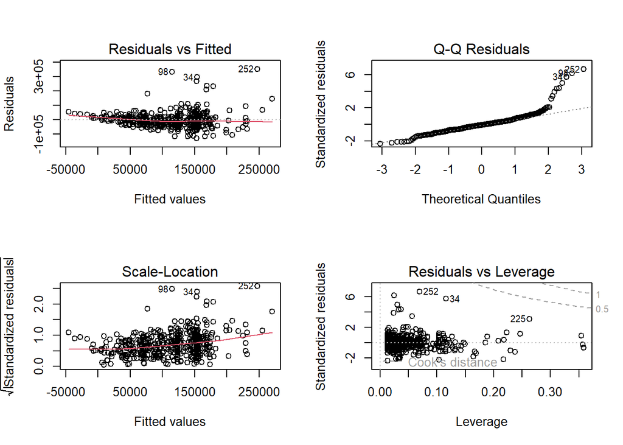

```r
par(mfrow = c(2, 2)); plot(ols_raw); par(mfrow = c(1, 1))
```

Every check fails. Residual normality is rejected at astronomical significance (*p* ≈ 1.3·10⁻²¹), errors are heteroskedastic (BP = 41.6, *p* = 0.010), and the largest Cook’s distance reaches 0.18 - a handful of executive-level records visibly dominate the fitted line. An untransformed linear model is therefore not a trustworthy basis for inference or prediction.

### Choosing the response scale: Box–Cox analysis

The Box–Cox family asks which power $\text{salary}^{\lambda}$ makes the linear model most consistent with its assumptions:

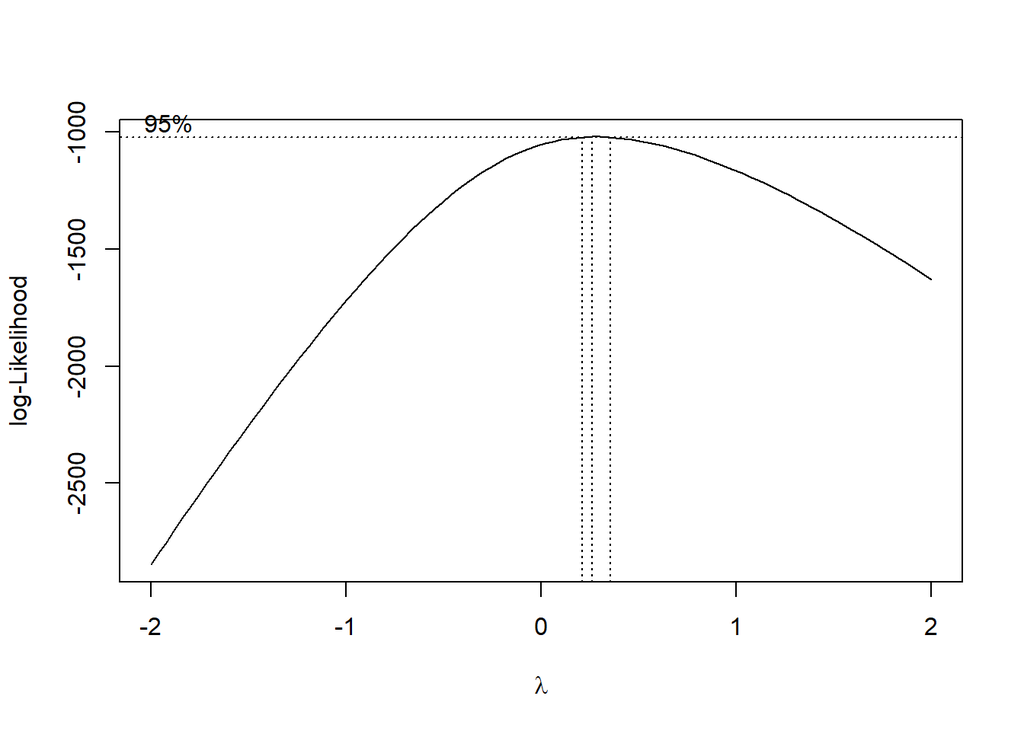

```r
bc <- MASS::boxcox(ols_raw, lambda = seq(-2, 2, length = 100), plotit = TRUE)
```

```r
lambda_hat <- bc$x[which.max(bc$y)]
## Profile-likelihood 95% confidence interval for lambda
cut_off  <- max(bc$y) - qchisq(0.95, 1) / 2
lambda_ci <- range(bc$x[bc$y >= cut_off])
cat("Box-Cox optimal lambda:", round(lambda_hat, 3), "\n")
```

```
## Box-Cox optimal lambda: 0.263
```

```r
cat("95% CI: [", round(lambda_ci[1], 3), ",", round(lambda_ci[2], 3), "]\n")
```

```
## 95% CI: [ 0.222 , 0.343 ]
```

The likelihood peaks at $\hat\lambda \approx 0.26$, with a 95% profile-likelihood interval $[0.22,\ 0.34]$ that excludes **both** special cases: $\lambda = 1$ (raw dollars, rejected above) and $\lambda = 0$ (the log). Formally, the data prefer an intermediate power. We adopt **ln(salary)** as the working response for its interpretable percentage coefficients, and give $\text{salary}^{0.26}$ the identical battery of assumption tests below; whether the intermediate power rivals ln(salary) out of sample is deferred to Task 6, which owns the held-out comparison.

### The regression on ln(salary)

```r
ols_full <- lm(log_salary ~ experience_level + job_category + employment_type +
                 company_size + location_group + remote_ratio + work_year + is_local,
               data = train)
summary(ols_full)
```

```
##
## Call:
## lm(formula = log_salary ~ experience_level + job_category + employment_type +
##     company_size + location_group + remote_ratio + work_year +
##     is_local, data = train)
##
## Residuals:
##      Min       1Q   Median       3Q      Max
## -2.52468 -0.22596  0.01623  0.28464  1.62159
##
## Coefficients:
##                               Estimate Std. Error t value Pr(>|t|)
## (Intercept)                 14.1094512 82.2631174   0.172 0.863899
## experience_levelMI           0.2185999  0.0738465   2.960 0.003246 **
## experience_levelSE           0.5030648  0.0773324   6.505 2.17e-10 ***
## experience_levelEX           0.9434264  0.1338966   7.046 7.43e-12 ***
## job_categoryData_Engineer    0.2857084  0.0710450   4.022 6.84e-05 ***
## job_categoryData_Scientist   0.3263454  0.0715932   4.558 6.74e-06 ***
## job_categoryManagement_Lead  0.4619912  0.0974181   4.742 2.88e-06 ***
## job_categoryML_AI_Engineer   0.4035535  0.0854178   4.724 3.14e-06 ***
## job_categoryOther            0.1873277  0.1565540   1.197 0.232138
## job_categoryResearch         0.5301837  0.1460875   3.629 0.000319 ***
## employment_typeCT            0.2669126  0.2226036   1.199 0.231174
## employment_typeFL           -1.0677591  0.2894382  -3.689 0.000254 ***
## employment_typePT           -1.0982549  0.1947743  -5.639 3.12e-08 ***
## company_sizeM                0.1610002  0.0790103   2.038 0.042195 *
## company_sizeL                0.3002825  0.0744101   4.036 6.46e-05 ***
## location_groupCA             0.6343629  0.1230643   5.155 3.89e-07 ***
## location_groupDE             0.5204918  0.1305631   3.987 7.89e-05 ***
## location_groupES             0.0328985  0.1698395   0.194 0.846500
## location_groupFR             0.3151577  0.1523464   2.069 0.039176 *
## location_groupGB             0.5266983  0.1037569   5.076 5.76e-07 ***
## location_groupIN            -0.7325338  0.1210754  -6.050 3.16e-09 ***
## location_groupUS             0.9349577  0.0732668  12.761  < 2e-16 ***
## remote_ratio                 0.0009803  0.0005978   1.640 0.101772
## work_year                   -0.0022684  0.0407157  -0.056 0.955596
## is_local                     0.4129746  0.0858765   4.809 2.11e-06 ***
## ---
## Signif. codes:  0 '***' 0.001 '**' 0.01 '*' 0.05 '.' 0.1 ' ' 1
##
## Residual standard error: 0.4848 on 427 degrees of freedom
## Multiple R-squared:  0.6569, Adjusted R-squared:  0.6376
## F-statistic: 34.06 on 24 and 427 DF,  p-value: < 2.2e-16
```

The transformed model explains about **64% of the variation in log-salary** (adjusted R² = 0.638) and is highly significant overall (*F* = 34.1 on 24 and 427 df, *p* < 2.2 x 10⁻¹⁶) - a clear gain over the raw-scale reference, and a step up from the same design without `is_local` (adjusted R² = 0.619).

### Re-checking the assumptions after the transformation

```r
## The Box-Cox-optimal power scale receives the identical battery of tests,
## so the transformation choice is judged on evidence rather than habit.
z_train  <- train$salary_in_usd^lambda_hat
ols_power <- lm(z_train ~ experience_level + job_category + employment_type +
                  company_size + location_group + remote_ratio + work_year + is_local,
                data = train)
diag_power <- diag_row(paste0("salary^", round(lambda_hat, 2)), ols_power)
diag_log <- diag_row("ln(salary)", ols_full)
bind_rows(diag_raw, diag_power, diag_log)
```

| response | Shapiro_p | Jarque_Bera_p | BP_stat | BP_p | Max_Cooks_D |
| --- | --- | --- | --- | --- | --- |
| salary_in_usd | 1.30e-21 | 0 | 41.6 | 0.010100 | 0.180 |
| salary^0.26 | 1.85e-08 | 0 | 42.2 | 0.012200 | 0.072 |
| ln(salary) | 3.01e-13 | 0 | 54.7 | 0.000344 | 0.060 |

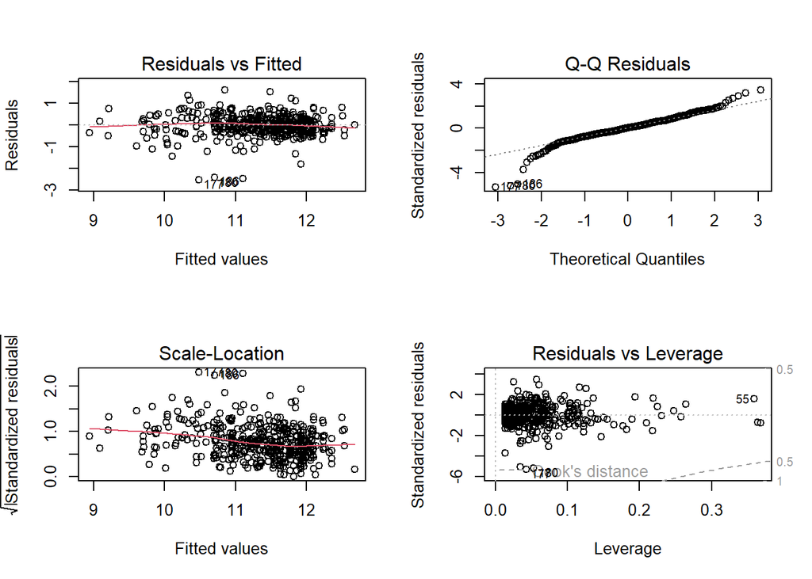

```r
par(mfrow = c(2, 2)); plot(ols_full); par(mfrow = c(1, 1))
```

```r
## Generalized VIFs: a property of the predictor design matrix, hence
## identical under any response scale — one table covers both models.
vif_raw <- car::vif(ols_full)
if (is.matrix(vif_raw)) {
  vif_tab <- tibble(
    term     = rownames(vif_raw),
    GVIF     = vif_raw[, "GVIF"],
    Df       = vif_raw[, "Df"],
    gvif_adj = vif_raw[, "GVIF^(1/(2*Df))"]
  )
} else {
  vif_tab <- tibble(term = names(vif_raw), GVIF = as.numeric(vif_raw),
                    Df = 1, gvif_adj = sqrt(as.numeric(vif_raw)))
}
vif_tab
```

| term | GVIF | Df | gvif_adj |
| --- | --- | --- | --- |
| experience_level | 1.723236 | 3 | 1.094941 |
| job_category | 1.858403 | 6 | 1.053000 |
| employment_type | 1.227562 | 3 | 1.034762 |
| company_size | 1.607472 | 2 | 1.125993 |
| location_group | 1.877732 | 7 | 1.046033 |
| remote_ratio | 1.136206 | 1 | 1.065930 |
| work_year | 1.590864 | 1 | 1.261295 |
| is_local | 1.118090 | 1 | 1.057398 |

### Refining the model by AIC

The full model contains two linear trend terms (`remote_ratio`, `work_year`) whose usefulness a parsimonious model should justify. Stepwise selection in both directions, guided by Akaike’s information criterion, removes exactly the survey-year term while keeping `remote_ratio`, all five factor blocks, and the `is_local` flag: the AIC improves from 654.5 to 652.5 at unchanged adjusted R² (0.638), i.e., the simpler model predicts equally well without the year trend.

```r
ols_step <- step(ols_full, direction = "both", trace = FALSE)
summary(ols_step)
```

```
##
## Call:
## lm(formula = log_salary ~ experience_level + job_category + employment_type +
##     company_size + location_group + remote_ratio + is_local,
##     data = train)
##
## Residuals:
##      Min       1Q   Median       3Q      Max
## -2.52532 -0.22673  0.01607  0.28419  1.62396
##
## Coefficients:
##                               Estimate Std. Error t value Pr(>|t|)
## (Intercept)                  9.5262917  0.1351282  70.498  < 2e-16 ***
## experience_levelMI           0.2182561  0.0735024   2.969 0.003152 **
## experience_levelSE           0.5023121  0.0760542   6.605 1.18e-10 ***
## experience_levelEX           0.9425037  0.1327134   7.102 5.17e-12 ***
## job_categoryData_Engineer    0.2856506  0.0709547   4.026 6.72e-05 ***
## job_categoryData_Scientist   0.3263707  0.0715084   4.564 6.56e-06 ***
## job_categoryManagement_Lead  0.4624575  0.0969447   4.770 2.53e-06 ***
## job_categoryML_AI_Engineer   0.4032449  0.0851386   4.736 2.96e-06 ***
## job_categoryOther            0.1872671  0.1563678   1.198 0.231733
## job_categoryResearch         0.5300372  0.1458936   3.633 0.000314 ***
## employment_typeCT            0.2677118  0.2218822   1.207 0.228272
## employment_typeFL           -1.0664483  0.2881441  -3.701 0.000243 ***
## employment_typePT           -1.0978758  0.1944286  -5.647 2.98e-08 ***
## company_sizeM                0.1593485  0.0731524   2.178 0.029928 *
## company_sizeL                0.2998677  0.0739506   4.055 5.96e-05 ***
## location_groupCA             0.6338565  0.1225850   5.171 3.59e-07 ***
## location_groupDE             0.5208321  0.1302682   3.998 7.52e-05 ***
## location_groupES             0.0332572  0.1695197   0.196 0.844559
## location_groupFR             0.3157848  0.1517529   2.081 0.038036 *
## location_groupGB             0.5262762  0.1033593   5.092 5.33e-07 ***
## location_groupIN            -0.7324424  0.1209232  -6.057 3.04e-09 ***
## location_groupUS             0.9345496  0.0728147  12.835  < 2e-16 ***
## remote_ratio                 0.0009787  0.0005964   1.641 0.101534
## is_local                     0.4126323  0.0855566   4.823 1.97e-06 ***
## ---
## Signif. codes:  0 '***' 0.001 '**' 0.01 '*' 0.05 '.' 0.1 ' ' 1
##
## Residual standard error: 0.4842 on 428 degrees of freedom
## Multiple R-squared:  0.6569, Adjusted R-squared:  0.6384
## F-statistic: 35.62 on 23 and 428 DF,  p-value: < 2.2e-16
```

```r
cat("\nTerms dropped (full model -> stepwise model):",
    setdiff(attr(terms(ols_full), "term.labels"),
            attr(terms(ols_step), "term.labels")), "\n")
```

```
##
## Terms dropped (full model -> stepwise model): work_year
```

```r
tibble(
  model   = c("Full OLS", "Stepwise-reduced OLS"),
  AIC     = c(AIC(ols_full), AIC(ols_step)),
  adj_R2  = c(summary(ols_full)$adj.r.squared, summary(ols_step)$adj.r.squared),
  n_terms = c(length(attr(terms(ols_full), "term.labels")),
              length(attr(terms(ols_step), "term.labels")))
)
```

| model | AIC | adj_R2 | n_terms |
| --- | --- | --- | --- |
| Full OLS | 654.5134 | 0.6375700 | 8 |
| Stepwise-reduced OLS | 652.5167 | 0.6384142 | 7 |

### Robust inference under unequal error variances

Unequal error variances invalidate ordinary standard errors, so the coefficient table below is accompanied by HC1-robust (heteroskedasticity-consistent) ones:

```r
robust_se <- lmtest::coeftest(ols_step, vcov = sandwich::vcovHC(ols_step, type = "HC1"))
cat("HC1-robust inference for the stepwise-selected ln(salary) model:\n")
```

```
## HC1-robust inference for the stepwise-selected ln(salary) model:
```

```r
print(robust_se)
```

```
##
## t test of coefficients:
##
##                                Estimate  Std. Error t value  Pr(>|t|)
## (Intercept)                  9.52629174  0.19174087 49.6832 < 2.2e-16 ***
## experience_levelMI           0.21825605  0.08305500  2.6278 0.0089015 **
## experience_levelSE           0.50231207  0.07775237  6.4604 2.844e-10 ***
## experience_levelEX           0.94250368  0.11671796  8.0751 6.914e-15 ***
## job_categoryData_Engineer    0.28565058  0.06146590  4.6473 4.485e-06 ***
## job_categoryData_Scientist   0.32637066  0.06389777  5.1077 4.920e-07 ***
## job_categoryManagement_Lead  0.46245749  0.08365614  5.5281 5.639e-08 ***
## job_categoryML_AI_Engineer   0.40324492  0.08965161  4.4979 8.851e-06 ***
## job_categoryOther            0.18726711  0.13601516  1.3768 0.1692906
## job_categoryResearch         0.53003725  0.17085958  3.1022 0.0020482 **
## employment_typeCT            0.26771179  0.18738336  1.4287 0.1538242
## employment_typeFL           -1.06644831  0.27076114 -3.9387 9.563e-05 ***
## employment_typePT           -1.09787585  0.21762594 -5.0448 6.722e-07 ***
## company_sizeM                0.15934851  0.09184349  1.7350 0.0834606 .
## company_sizeL                0.29986775  0.09232463  3.2480 0.0012538 **
## location_groupCA             0.63385647  0.13126210  4.8289 1.914e-06 ***
## location_groupDE             0.52083212  0.13467713  3.8673 0.0001272 ***
## location_groupES             0.03325718  0.14076010  0.2363 0.8133373
## location_groupFR             0.31578484  0.14890116  2.1208 0.0345158 *
## location_groupGB             0.52627620  0.12244223  4.2982 2.134e-05 ***
## location_groupIN            -0.73244244  0.14783439 -4.9545 1.046e-06 ***
## location_groupUS             0.93454962  0.10890884  8.5810 < 2.2e-16 ***
## remote_ratio                 0.00097871  0.00062379  1.5690 0.1173904
## is_local                     0.41263225  0.13257048  3.1126 0.0019791 **
## ---
## Signif. codes:  0 '***' 0.001 '**' 0.01 '*' 0.05 '.' 0.1 ' ' 1
```

### What drives salaries?

Because the response is a logarithm, each coefficient translates into an approximate percentage change in salary through $100\,(e^{\beta}-1)$:

```r
coef_pct <- broom::tidy(ols_step) %>%
  mutate(pct_effect = 100 * (exp(estimate) - 1)) %>%
  dplyr::select(term, estimate, p.value, pct_effect)
print(coef_pct, n = 30)
```

```
## # A tibble: 24 × 4
##    term                         estimate   p.value   pct_effect
##    <chr>                           <dbl>     <dbl>        <dbl>
##  1 (Intercept)                  9.53     1.08e-237 1371464.
##  2 experience_levelMI           0.218    3.15e-  3      24.4
##  3 experience_levelSE           0.502    1.18e- 10      65.3
##  4 experience_levelEX           0.943    5.17e- 12     157.
##  5 job_categoryData_Engineer    0.286    6.72e-  5      33.1
##  6 job_categoryData_Scientist   0.326    6.56e-  6      38.6
##  7 job_categoryManagement_Lead  0.462    2.53e-  6      58.8
##  8 job_categoryML_AI_Engineer   0.403    2.96e-  6      49.7
##  9 job_categoryOther            0.187    2.32e-  1      20.6
## 10 job_categoryResearch         0.530    3.14e-  4      69.9
## 11 employment_typeCT            0.268    2.28e-  1      30.7
## 12 employment_typeFL           -1.07     2.43e-  4     -65.6
## 13 employment_typePT           -1.10     2.98e-  8     -66.6
## 14 company_sizeM                0.159    2.99e-  2      17.3
## 15 company_sizeL                0.300    5.96e-  5      35.0
## 16 location_groupCA             0.634    3.59e-  7      88.5
## 17 location_groupDE             0.521    7.52e-  5      68.3
## 18 location_groupES             0.0333   8.45e-  1       3.38
## 19 location_groupFR             0.316    3.80e-  2      37.1
## 20 location_groupGB             0.526    5.33e-  7      69.3
## 21 location_groupIN            -0.732    3.04e-  9     -51.9
## 22 location_groupUS             0.935    3.98e- 32     155.
## 23 remote_ratio                 0.000979 1.02e-  1       0.0979
## 24 is_local                     0.413    1.97e-  6      51.1
```

Four patterns stand out.

**Experience dominates.** Relative to an entry-level professional, mid-level colleagues earn about 24% more, seniors about 65% more, and executives about 157% more — a steep, strictly increasing gradient that makes seniority the single strongest career-side lever in the data.

**Role matters within the field.** Against the Data-Analyst baseline, moving into engineering (+33%) or science (+39%) pays moderately; specializing in machine learning/AI (+50%), leading teams (+59%), or research (+70%) pays substantially more. The heterogeneous “Other” category is statistically indistinguishable from analysts, which supports keeping it separate rather than forcing it into another family.

**Contract structure shapes pay.** Part-time (−67%) and freelance (−66%) arrangements earn far less than full-time contracts, consistent with partial-year or project-based engagement; contract work shows a positive but unreliable premium (+31%), unsurprising given only five such records.

**Residence-match carries its own premium.** Being employed where you live is worth roughly **51% more** than an otherwise identical posting at an overseas employer (*p* = 2·10⁻⁶ ordinary, *p* = 0.0020 robust) — the regression’s confirmation that the cross-border gap Task 6 finds on the same split is a real structural feature, not an artifact of which countries appear.

## 4.3 Polynomial Regression

Stepwise selection dropped the survey-year trend but kept `remote_ratio`; that raises a subtler question: is the remaining trend relationship curved? Polynomial regression answers it by allowing `remote_ratio` and `work_year` each to bend instead of following a straight line. Both variables take exactly three distinct values (0/50/100 and 2020/2021/2022), so degree 3 is not identifiable; degree 2 is the ceiling and effectively lets every level carry its own effect. We compare the linear and quadratic specifications with the nested *F*-test.

```r
base_terms <- setdiff(attr(terms(ols_step), "term.labels"), c("remote_ratio", "work_year"))
base_formula_str <- paste("log_salary ~", paste(base_terms, collapse = " + "))

fit_poly <- function(degree) {
  f <- as.formula(paste0(base_formula_str,
                          " + poly(remote_ratio, ", degree, ")",
                          " + poly(work_year, ", degree, ")"))
  lm(f, data = train)
}

poly_linear    <- fit_poly(1)   # straight-line benchmark
poly_quadratic <- fit_poly(2)   # quadratic alternative

tibble(
  degree = c(1, 2),
  AIC    = c(AIC(poly_linear), AIC(poly_quadratic)),
  adj_R2 = c(summary(poly_linear)$adj.r.squared, summary(poly_quadratic)$adj.r.squared)
)
```

| degree | AIC | adj_R2 |
| --- | --- | --- |
| 1 | 654.5134 | 0.6375700 |
| 2 | 653.2646 | 0.6400685 |

```r
anova_poly <- anova(poly_linear, poly_quadratic)
anova_poly
```

|  | Res.Df | RSS | Df | Sum of Sq | F | Pr(>F) |
| --- | --- | --- | --- | --- | --- | --- |
| 1 | 427 | 100.36357 | NA | NA | NA | NA |
| 2 | 425 | 99.20486 | 2 | 1.158711 | 2.481995 | 0.08478706 |

```r
poly_model <- if (anova_poly$`Pr(>F)`[2] < 0.05) poly_quadratic else poly_linear

reset_result <- lmtest::resettest(poly_model)
cat("\nRESET test on selected model: F =", round(reset_result$statistic, 3),
    " p =", signif(reset_result$p.value, 4), "\n")
```

```
##
## RESET test on selected model: F = 1.99  p = 0.138
```

## 4.4 Ridge and LASSO Regression

Ordinary least squares treats all 21 columns as free parameters. Shrinkage methods trade a little bias for variance reduction and, in the LASSO’s case, automatic variable selection — a useful cross-check on the stepwise route. They require standardized inputs: all four numeric predictors are z-scored with training means and standard deviations, applied unchanged to the test records.

```r
## Training-only z-scaling of every numeric input; the identical transform
## is applied to test.
tr_scale <- function(col) {
  m <- mean(train[[col]]); s <- sd(train[[col]])
  list(train = (train[[col]] - m) / s, test = (test[[col]] - m) / s)
}
for (col in c("exp_level_ord", "company_size_ord", "remote_ratio", "work_year")) {
  sc <- tr_scale(col)
  train[[paste0(col, "_ts")]] <- sc$train
  test[[paste0(col, "_ts")]]  <- sc$test
}

build_matrix <- function(df) {
  model.matrix(
    ~ exp_level_ord_ts + company_size_ord_ts + remote_ratio_ts +
      work_year_ts + job_category + employment_type + location_group + is_local,
    data = df
  )[, -1]   # glmnet supplies its own intercept
}

x_train <- build_matrix(train)
x_test  <- build_matrix(test)
y_train <- train$log_salary
y_test  <- test$log_salary
dim(x_train); dim(x_test)
```

```
## [1] 452  21
```

```
## [1] 113  21
```

The penalty strength λ is tuned by ten-fold cross-validation within the training set; prediction uses `lambda.min`, with the sparser `lambda.1se` reported for reference.

```r
set.seed(2026)
cv_ridge <- cv.glmnet(x_train, y_train, alpha = 0, nfolds = 10)
set.seed(2026)
cv_lasso <- cv.glmnet(x_train, y_train, alpha = 1, nfolds = 10)

cat("Ridge: lambda.min =", cv_ridge$lambda.min, " lambda.1se =", cv_ridge$lambda.1se, "\n")
```

```
## Ridge: lambda.min = 0.04379278  lambda.1se = 0.3721307
```

```r
cat("LASSO: lambda.min =", cv_lasso$lambda.min, " lambda.1se =", cv_lasso$lambda.1se, "\n")
```

```
## LASSO: lambda.min = 0.002392083  lambda.1se = 0.03552167
```

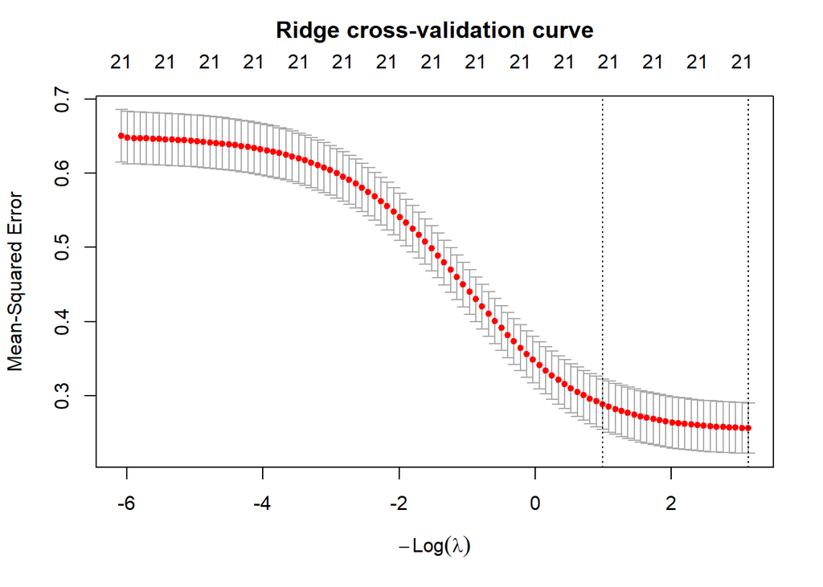

```r
plot(cv_ridge); title("Ridge cross-validation curve", line = 2.5)
```

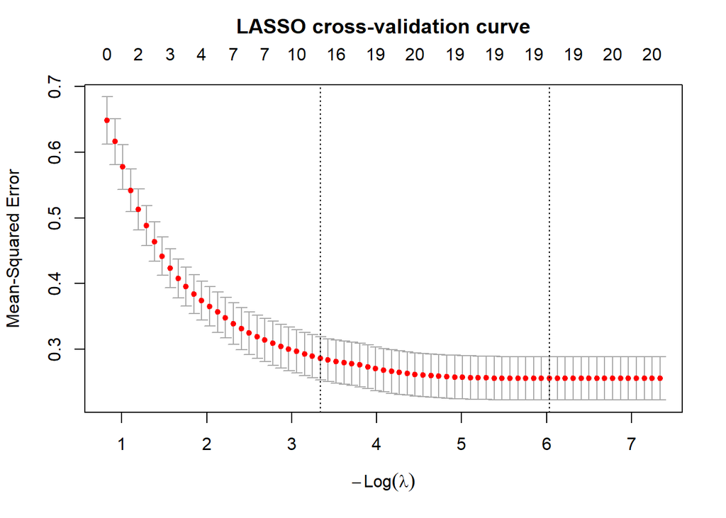

```r
plot(cv_lasso); title("LASSO cross-validation curve", line = 2.5)
```

```r
## Robustness of the endpoint choice: a sweep over the full elastic-net
## mixing range finds the CV surface flat, so neither pure penalty is a
## lucky guess.
enet_sweep <- vapply(seq(0, 1, by = 0.1), function(a) {
  set.seed(2026)
  sqrt(min(cv.glmnet(x_train, y_train, alpha = a, nfolds = 10)$cvm))
}, numeric(1))
cat("CV RMSE across alpha = 0,0.1,...,1:",
    sprintf("%.4f-%.4f (range %.4f)", min(enet_sweep), max(enet_sweep),
            diff(range(enet_sweep))), "\n")
```

```
## CV RMSE across alpha = 0,0.1,...,1: 0.5054-0.5063 (range 0.0008)
```

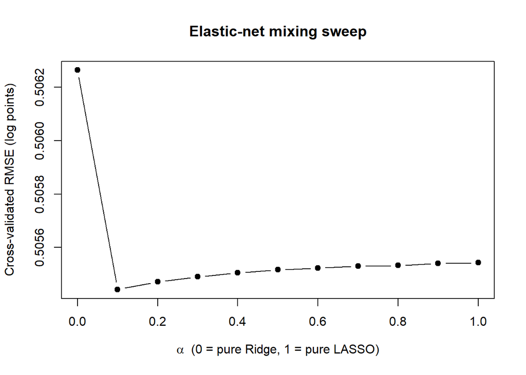

```r
plot(seq(0, 1, by = 0.1), enet_sweep, type = "b", pch = 19,
     xlab = expression(alpha * "  (0 = pure Ridge, 1 = pure LASSO)"),
     ylab = "Cross-validated RMSE (log points)",
     main = "Elastic-net mixing sweep")
```

```r
## Tuned elastic net: alpha picked by the same 10-fold CV, kept alongside its
## two pure-parent special cases for Task 6 to score.
alpha_best <- seq(0, 1, by = 0.1)[which.min(enet_sweep)]
set.seed(2026)
cv_elastic <- cv.glmnet(x_train, y_train, alpha = alpha_best, nfolds = 10)
cat("Selected elastic-net alpha:", alpha_best,
    "| predictor columns kept at lambda.min:",
    sum(as.numeric(coef(cv_elastic, s = "lambda.min"))[-1] != 0), "/", ncol(x_train), "\n")
```

```
## Selected elastic-net alpha: 0.1 | predictor columns kept at lambda.min: 20 / 21
```

Sweeping the mixing parameter across its full range ($\alpha$ = 0, 0.1, …, 1) moves the cross-validated error by about 0.16%, and nearly every column survives at $\lambda_{\min}$ (19–21 of the 21 columns), with the flat `work_year_ts` and `location_groupES` effects the only ones ever shrunk all the way to zero. With the surface this flat there is no meaningful interior optimum; the CV-selected mixture ($\alpha$ = 0.1) is carried forward for Task 6 to score alongside the other specifications.

Which variables survive the LASSO penalty, and do they agree with the stepwise choice? Since LASSO names individual dummy columns while stepwise names whole variables, survivors are first mapped back to their parent variables before comparing.

```r
lasso_coefs_min <- coef(cv_lasso, s = "lambda.min")
lasso_survivors <- setdiff(rownames(lasso_coefs_min)[which(lasso_coefs_min[, 1] != 0)],
                           "(Intercept)")
cat("LASSO retains", length(lasso_survivors), "of", nrow(lasso_coefs_min) - 1,
    "columns at lambda.min\n")
```

```
## LASSO retains 19 of 21 columns at lambda.min
```

```r
parent_terms <- c("exp_level_ord_ts", "company_size_ord_ts",
                  "remote_ratio_ts", "work_year_ts",
                  "job_category", "employment_type", "location_group",
                  "is_local")
map_to_parent <- function(dummy_names) {
  vapply(dummy_names, function(nm) {
    hit <- parent_terms[startsWith(nm, parent_terms)]
    if (length(hit) == 0) nm else hit[which.max(nchar(hit))]
  }, character(1), USE.NAMES = FALSE)
}
canonical <- c(exp_level_ord_ts         = "experience_level",
               company_size_ord_ts      = "company_size",
               remote_ratio_ts          = "remote_ratio",
               work_year_ts             = "work_year")
lasso_parents <- unique(map_to_parent(lasso_survivors))
lasso_parents <- unique(ifelse(lasso_parents %in% names(canonical),
                               canonical[lasso_parents], lasso_parents))
stepwise_terms <- attr(terms(ols_step), "term.labels")

cat("Selected by BOTH:", intersect(stepwise_terms, lasso_parents), "\n")
```

```
## Selected by BOTH: experience_level job_category employment_type company_size location_group remote_ratio is_local
```

```r
cat("Stepwise only:",     setdiff(stepwise_terms, lasso_parents), "\n")
```

```
## Stepwise only:
```

```r
cat("LASSO only:        ", setdiff(lasso_parents, stepwise_terms), "\n")
```

```
## LASSO only:
```

The two selection philosophies now converge exactly: both retain the same seven blocks — experience level, job family, contract type, company size, location, remote ratio, and the `is_local` flag — and both discard the survey-year term (AIC by dropping `work_year`, LASSO by shrinking `work_year_ts` exactly to zero alongside the flat `location_groupES` dummy). The agreement is no longer cosmetic: stepwise and LASSO nominate the identical variable set.

A final sensitivity check replaces the ordinal encodings of experience and company size with full dummies inside the LASSO, the two variants being compared by ten-fold cross-validation on the training data. Accuracy hardly moves (CV RMSE 0.5055 vs 0.5077): the ordinal simplification costs nothing predictive.

```r
build_matrix_factor <- function(df) {
  model.matrix(
    ~ experience_level + company_size + remote_ratio_ts + work_year_ts +
      job_category + employment_type + location_group + is_local,
    data = df
  )[, -1]
}
x_train_f <- build_matrix_factor(train)

set.seed(2026)
cv_lasso_factor <- cv.glmnet(x_train_f, y_train, alpha = 1, nfolds = 10)

cat("LASSO CV RMSE (log scale, training folds):\n")
```

```
## LASSO CV RMSE (log scale, training folds):
```

```r
cat("  ordinal encoding:", round(sqrt(min(cv_lasso$cvm)), 4),
    "| factor-dummy encoding:", round(sqrt(min(cv_lasso_factor$cvm)), 4), "\n")
```

```
##   ordinal encoding: 0.5055 | factor-dummy encoding: 0.5077
```

## 4.5 Summary of training-set fit

This task constructs the candidate models, verifies their assumptions, and interprets the drivers on the training data; formal scoring of the held-out records and the final model choice belong to Task 6. To close the modeling here, the table below summarizes how well each specification fits the 452 training rows. Because every model except the power transform shares `log_salary` as its response, their R² and adjusted R² are directly comparable on the log scale. AIC - which rewards fit while penalizing parameter count - is reported for the three ordinary least-squares fits where it is defined; it is not defined for the penalty-regularized Ridge/LASSO/elastic-net fits, whose effective parameter count is not the number of columns.

```r
pred_tr <- list(
  `Full OLS - stepwise`         = predict(ols_step),
  `Full OLS`                    = predict(ols_full),
  `Polynomial regression`       = predict(poly_model),
  `Ridge regression`            = as.numeric(predict(cv_ridge, newx = x_train, s = "lambda.min")),
  `LASSO regression`            = as.numeric(predict(cv_lasso, newx = x_train, s = "lambda.min")),
  `Elastic net regression`      = as.numeric(predict(cv_elastic, newx = x_train, s = "lambda.min"))
)

fit_row <- function(model, fit, y, n_coef, aic_val) {
  n    <- length(y)
  rss  <- sum((y - fit)^2)
  r2   <- 1 - rss / sum((y - mean(y))^2)
  adj  <- 1 - (1 - r2) * (n - 1) / (n - n_coef - 1)
  tibble(model = model,
         R2     = signif(r2, 4),
         adj_R2 = signif(adj, 4),
         n_par  = n_coef,
         AIC    = aic_val)
}

p_full <- length(coef(ols_full))
p_step <- length(coef(ols_step))
p_poly <- length(coef(poly_model))

train_fit <- bind_rows(
  fit_row("Multiple linear regression - full",      pred_tr[["Full OLS"]],            y_train, p_full, round(AIC(ols_full), 1)),
  fit_row("Multiple linear regression - stepwise",  pred_tr[["Full OLS - stepwise"]],  y_train, p_step, round(AIC(ols_step), 1)),
  fit_row("Polynomial regression",                  pred_tr[["Polynomial regression"]], y_train, p_poly, round(AIC(poly_model), 1)),
  fit_row("Ridge regression",                       pred_tr[["Ridge regression"]],      y_train, ncol(x_train), NA),
  fit_row("LASSO regression",                       pred_tr[["LASSO regression"]],      y_train, ncol(x_train), NA),
  fit_row("Elastic net regression",                 pred_tr[["Elastic net regression"]], y_train, ncol(x_train), NA)
)
train_fit
```

| model | R2 | adj_R2 | n_par | AIC |
| --- | --- | --- | --- | --- |
| Multiple linear regression - full | 0.6569 | 0.6367 | 25 | 654.5 |
| Multiple linear regression - stepwise | 0.6569 | 0.6376 | 24 | 652.5 |
| Polynomial regression | 0.6569 | 0.6367 | 25 | 654.5 |
| Ridge regression | 0.6506 | 0.6335 | 21 | NA |
| LASSO regression | 0.6543 | 0.6374 | 21 | NA |
| Elastic net regression | 0.6542 | 0.6373 | 21 | NA |

```r
cat("\nNote: the Box-Cox power-scale model (Section 4.2) is fitted on\n")
```

```
##
## Note: the Box-Cox power-scale model (Section 4.2) is fitted on
```

```r
cat("a different response scale, so its in-sample R2 is not directly\n")
```

```
## a different response scale, so its in-sample R2 is not directly
```

```r
cat("comparable with the log-salary models above and is omitted here; the\n")
```

```
## comparable with the log-salary models above and is omitted here; the
```

```r
cat("held-out comparison across scales is deferred to Task 6.\n")
```

```
## held-out comparison across scales is deferred to Task 6.
```

Three points follow. First, the **stepwise-reduced model matches the full model on training data** - equal adjusted R² (0.638) at a slightly lower AIC (652.5 vs 654.5) with one fewer parameter - so the pruning costs no in-sample fit while removing the marginal survey-year trend, the qualitative conclusion of Section 4.2. Second, the **regularized fits show essentially identical training R² to the OLS variants** (all in the range 0.651–0.657), as expected: shrinkage buys stability rather than in-sample fit, and their advantage, if any, materializes out of sample — which Task 6 measures. Third, **adjusted R² falls below R² by only a small margin** (about 0.02), because the models’ predictor count is modest relative to 452 training rows, so none of the candidates is badly over-parameterized in sample. In short, on the training data the candidate models are nearly indistinguishable in fit; their separation must come from held-out performance, which Task 6 evaluates.

```r
write.csv(train, "dataset/train_data.csv", row.names = FALSE)
write.csv(test, "dataset/test_data.csv", row.names = FALSE)
```